# title goes here

## **4. IMPROVEMENT**

Keep in mind these athletes are already performing at a high level. The better your initial performance, the less your improvement will be. An athlete who runs a four-minute mile can only marginally improve their time, while the athlete who runs a ten-minute mile can perhaps improve their time by a significant amount.

Figure 6 depicts the historical distribution of improvements from grade to grade.

Figure 6

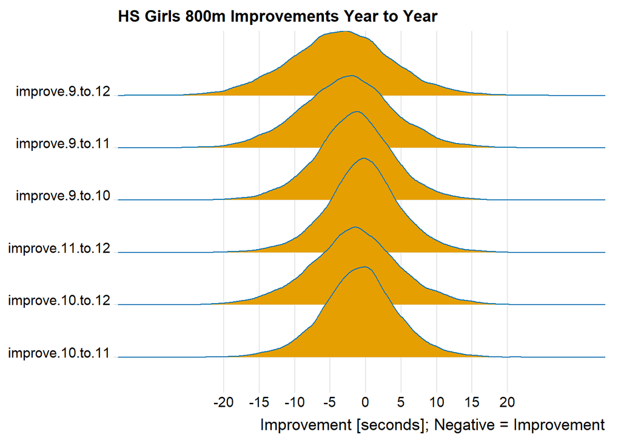

## **5. COLLEGE COMPARISON**

How well did college athletes in Girls High School outdoor 800 meters perform when they were in high school? Figure 7 looks at Division 1, Division 2, and Division 3 college athletes and their performances in the 800m when they were in high school.

Figure 7

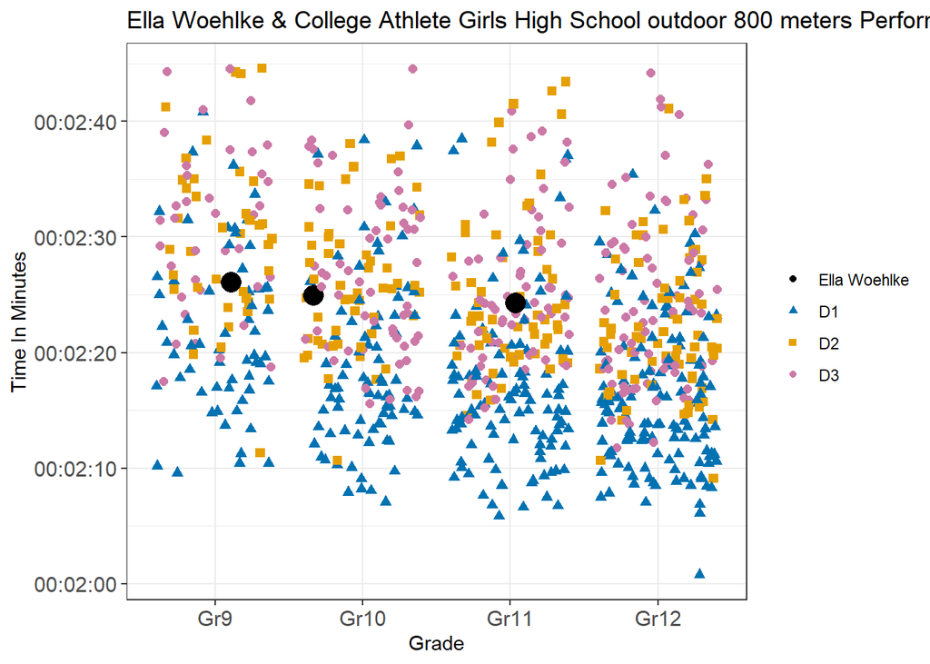

Taking it a step further, how did the collegiate All-Conference and All-American athletes in this event perform when they were in high school? Figure 8 shows the high school performances of future Division 1, 2, and 3 elite athletes in 800m.

Figure 8

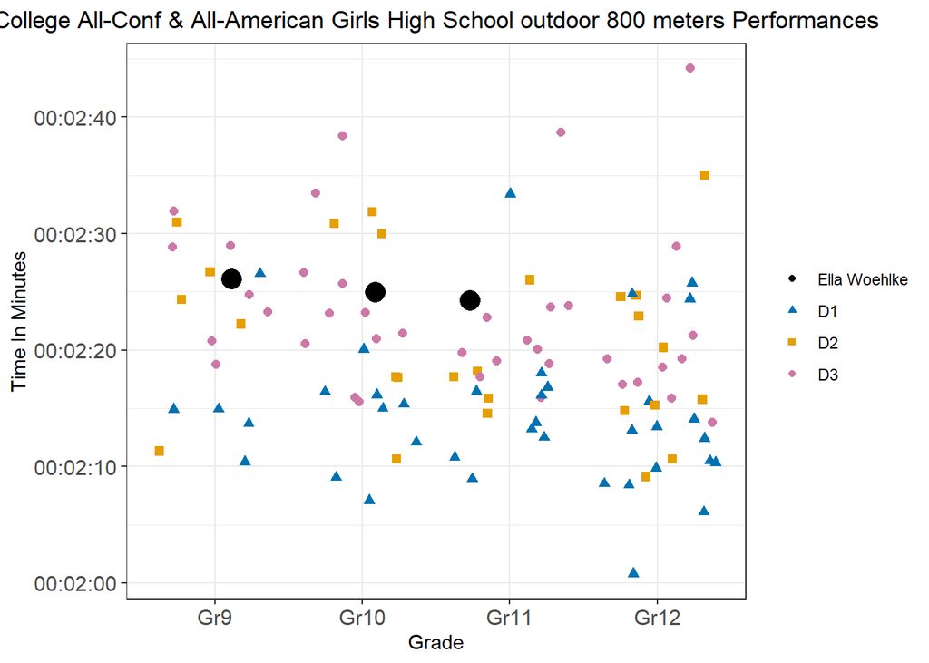

The boxplot in Figure 9 show the distribution of performances for D1, D2, and D3 athletes when they were in grades 9 - 12. It also includes a distribution of performances for your athlete's school in the years 2011 - 2019.

Figure 9

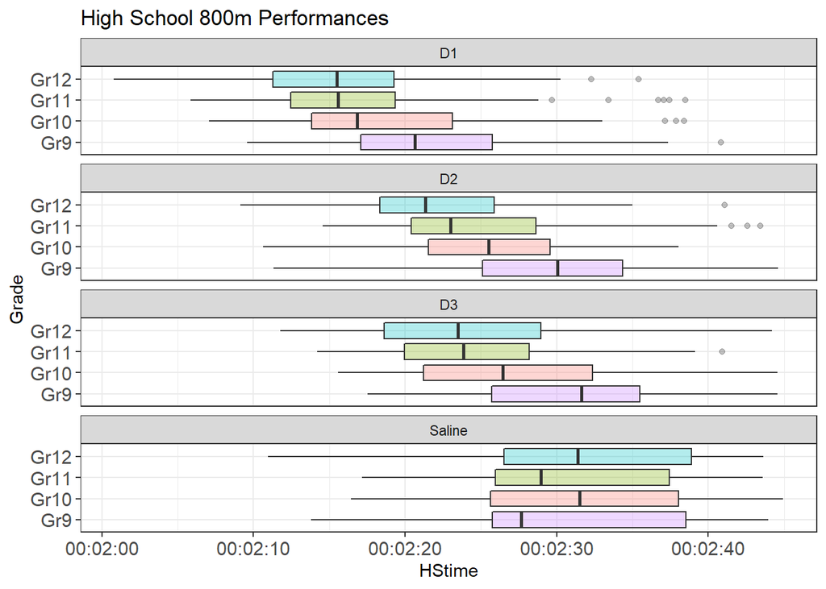

Finally, what were the typical performances, by high school grade, of those who went on to be collegiate track and field athletes? Figure 10 sheds some insight.

Figure 10

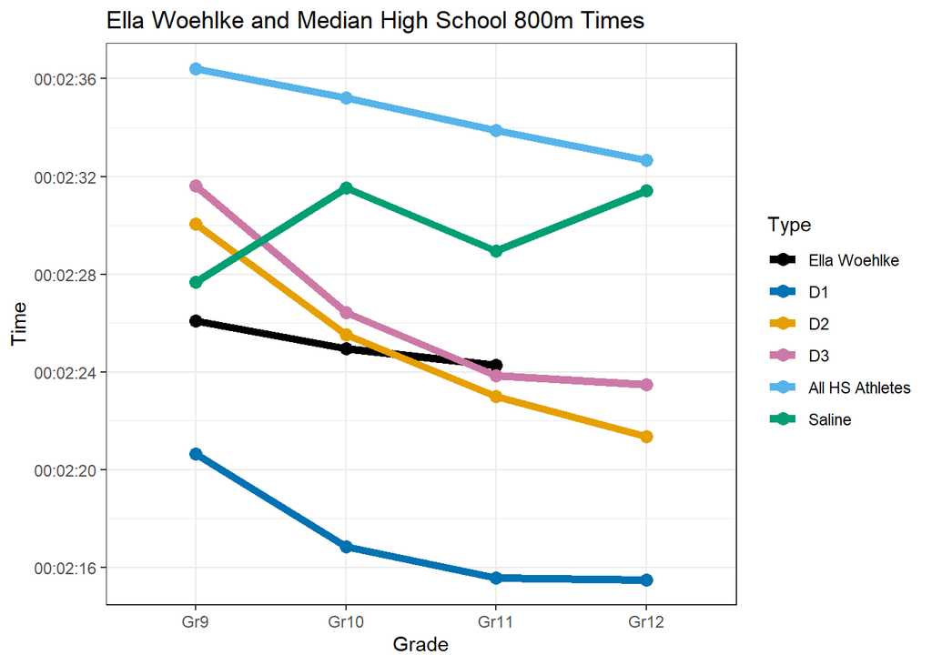

## **6. PREDICTIONS**

Based solely on the data, what is your athlete predicted to run next season as a 12th grader?

I really hesitate to provide a prediction. The high school years can be fraught with enough anxiety as it is, without some random guy on the internet saying that your athlete is predicted to perform at a certain level.

Disclaimers. There are a million reasons why your athlete may far surpass the prediction below, and there are a million reasons why your athlete may not achieve the prediction.

The prediction(s) below do not and cannot measure:

- If an athlete was injured last year and therefore did not perform well
- If an athlete is injured this year and therefore cannot perform as well as last year
- The fact that puberty comes at different grades and ages
- The quality of an athlete's training
- The quantity of an athlete's training
- Factors in personal lives of athletes that may affect performance
- Nutrition levels of an athlete
- Many other factors

Please take the prediction with a grain of salt.

I used a linear regression model to predict future performances. This model performed better than other machine learning methodologies, including random forest, on training data.

By the numbers, and only by the numbers, the prediction for Ella Woehlke in Grade 12 800m is:

### 00:02:23.72

## **7. PROBABILITIES**

I wanted to take the prediction a step further to determine the likelihood of achieving certain levels of performance. What is the probability your athlete being able to incrementally improve their performance?

I took the data from 2011 - 2019 and ran a logistic regression model for various levels of performance in the Girls High School outdoor 800 meters. As shown in Figure 11, the model then calculated the likelihood of your athlete achieving these levels.

Figure 11

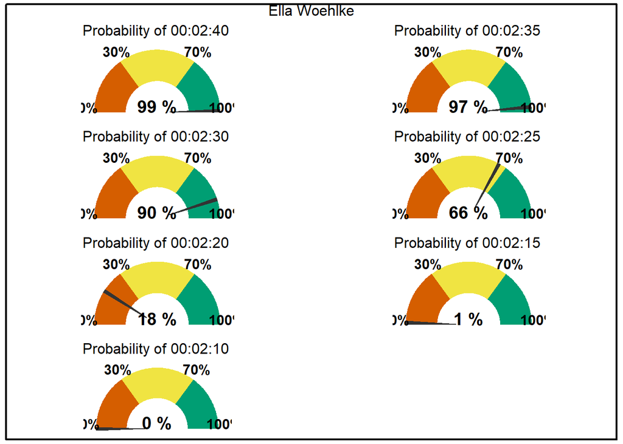